# Preprocess Melanoma data for cell type deconvolution

Ningshan Li & Nating Wang & Yunqing Liu

2023/03/21

In this R Notebook we preprocess spatial and corresponding reference scRNA-seq data of human **Melanoma** for cell type deconvolution.

1. **Spatial data preprocessing**:

   1.1 Input original data files
   - Raw nUMI of spatial spots: `ST_mel1_rep2_counts.tsv` is from zipped file ST-Melanoma-Datasets_1.zip downloaded from [Spatial Research website](https://www.spatialresearch.org/resources-published-datasets/doi-10-1158-0008-5472-can-18-0747/), and **second replicate from biopsy 1** is selected for analysis.

   1.2 Output data files for cell type deconvolution
   - Raw nUMI of spatial spots: Melanoma_spatial_spot_nUMI.csv. **No filtering on spots or genes**, i.e. all spots and genes are preserved.
   - Physical location of spatial spots: Melanoma_spatial_spot_loc.csv. The spatial `x` and `y` coordinates are directly extracted from spot names.
   - Adjacency Matrix: Melanoma_spatial_spot_adjacency_matrix.csv. Spots within neighborhood are adjacent **left**, **right**, **top** and **bottom** spots.
2. **Reference scRNA-seq data preprocessing**:

   2.1 Input original data files

   scRNA-seq data are downloaded from GSE115978.
   - Raw nUMI of all 7,186 single cells: [GSE115978_counts.csv.gz](https://www.ncbi.nlm.nih.gov/geo/download/?acc=GSE115978&format=file&file=GSE115978%5Fcounts%2Ecsv%2Egz)
   - Meta data of all 7,186 cells: [GSE115978_cell.annotations.csv.gz](https://www.ncbi.nlm.nih.gov/geo/download/?acc=GSE115978&format=file&file=GSE115978%5Fcell%2Eannotations%2Ecsv%2Egz)

   2.2 Output data files for cell type deconvolution

   We select **2,495** cells from 8 samples, and re-annotate cells with unknown cell type “?”. **NO filtering on genes**, i.e. all genes are included for analysis.
   - Raw nUMI of 2,495 cells with 7 cell types and 23,686 genes: Melanoma_ref_scRNA_cell_nUMI.csv.gz.
   - Cell type annotation for those 2,495 cells: Melanoma_ref_scRNA_cell_celltype.csv.

# 1 Version

```r
version[['version.string']]
```

```
[1] "R version 4.2.2 Patched (2022-11-10 r83330)"
```

# 2 Proprocess Melanoma spatial dataset

## 2.1 Read original data file `ST_mel1_rep2_counts.tsv`

- WARNING: gene with same Gene Symbol but mapping to 2 different Ensembl IDs are found! Total 19 genes are renamed!

```r
file_name = file.path(home.dir, 'ST_mel1_rep2_counts.tsv')
org_data = read.csv(file_name, sep = '\t', check.names = F, header = T)
print(sprintf('load data from %s', file_name))
```

```
[1] "load data from /home/hill103/Documents/SharedFolder/ToHost/CVAE-GLRM_Analysis/RealData/Melanoma/ST_mel1_rep2_counts.tsv"
```

```r
spot_names = colnames(org_data)[2:ncol(org_data)]

# extract first column as row name
org_data = org_data %>%
  tidyr::separate_wider_delim(gene, ' ', names = c('gene_name', NA), cols_remove = F)

org_data$duplicated = duplicated(org_data$gene_name)
duplicated_genes = org_data[org_data$duplicated, 'gene_name', drop=T]
org_data$gene_unique = make.unique(org_data$gene_name)
org_data$row = seq_len(nrow(org_data))

for_show = org_data[org_data$gene_name %in% duplicated_genes, c('row', 'gene', 'gene_unique')]
for_show[order(for_show$gene_unique), ]
```

| row | gene | gene_unique |
| --- | --- | --- |
| 677 | CBS ENSG00000274276 | CBS |
| 15528 | CBS ENSG00000160200 | CBS.1 |
| 7048 | DGCR6 ENSG00000278817 | DGCR6 |
| 7807 | DGCR6 ENSG00000183628 | DGCR6.1 |
| 3798 | HIST2H2AA4 ENSG00000203812 | HIST2H2AA4 |
| 4149 | HIST2H2AA4 ENSG00000272196 | HIST2H2AA4.1 |
| 8433 | ICOSLG ENSG00000277117 | ICOSLG |
| 8480 | ICOSLG ENSG00000160223 | ICOSLG.1 |
| 7015 | IDS ENSG00000010404 | IDS |
| 13670 | IDS ENSG00000241489 | IDS.1 |

[output cut: 28 more lines]

```r
gene_order = org_data$gene_unique

org_data = org_data[, spot_names]
org_data = as.data.frame(data.table::transpose(org_data))
row.names(org_data) = spot_names
colnames(org_data) = gene_order

print(sprintf('spots: %d; genes: %d', nrow(org_data), ncol(org_data)))
```

```
[1] "spots: 293; genes: 16148"
```

```r
org_data[1:5, 1:5]
```

|  | PSME2 | CUEDC1 | RPLP1 | TM9SF3 | DEF8 |
| --- | --- | --- | --- | --- | --- |
| 7x15 | 2 | 0 | 21 | 0 | 0 |
| 7x16 | 0 | 0 | 13 | 0 | 0 |
| 7x17 | 0 | 0 | 13 | 0 | 0 |
| 7x18 | 0 | 1 | 18 | 0 | 1 |
| 8x13 | 0 | 0 | 10 | 0 | 0 |

## 2.2 Save files for deconvolution

### 2.2.1 Spatial spot nUMI

**No filtering on spots or genes**, directly save all spots and genes into file Melanoma_spatial_spot_nUMI.csv. **Rows as spatial spots and columns as genes**.

```r
write.csv(org_data, 'Melanoma_spatial_spot_nUMI.csv')
print(sprintf('save %d gene nUMIs of %d spatial spots into file %s', ncol(org_data), nrow(org_data), 'Melanoma_spatial_spot_nUMI.csv'))
```

```
[1] "save 16148 gene nUMIs of 293 spatial spots into file Melanoma_spatial_spot_nUMI.csv"
```

### 2.2.2 Physical Locations of spatial spots

Directly extract the spatial `x` and `y` coordinates from spot names, then save it into file Melanoma_spatial_spot_loc.csv.

```r
local_df = data.frame(names = row.names(org_data), row.names = row.names(org_data))
local_df = local_df %>%
  tidyr::separate_wider_delim(names, 'x', names = c('y', 'x'))
local_df = as.data.frame(local_df)
row.names(local_df) = row.names(org_data)

local_df['x'] = as.numeric(local_df$x)
local_df['y'] = as.numeric(local_df$y)

local_df[1:5, ]
```

|  | y | x |
| --- | --- | --- |
| 7x15 | 7 | 15 |
| 7x16 | 7 | 16 |
| 7x17 | 7 | 17 |
| 7x18 | 7 | 18 |
| 8x13 | 8 | 13 |

```r
write.csv(local_df, 'Melanoma_spatial_spot_loc.csv')
print(sprintf('save Physical Locations of spatial spots into file %s', 'Melanoma_spatial_spot_loc.csv'))
```

```
[1] "save Physical Locations of spatial spots into file Melanoma_spatial_spot_loc.csv"
```

### 2.2.3 Adjacency Matrix of spatial spots

We define the neighborhood of a spatial spot contains the adjacent **left**, **right**, **top** and **bottom** spot, that is, one spot has at most 4 neighbors.

The generated Adjacency Matrix `A` only contains **1** and **0**, where 1 represents corresponding two spots are adjacent spots according to the definition of neighborhood, while value 0 for non-adjacent spots. Note **all diagonal entries are 0s**.

Adjacency Matrix are saved into file Melanoma_spatial_spot_adjacency_matrix.csv.

```r
getNeighbour = function(array_row, array_col) {
  # based on the (row, col) of one spot, return the (row, col) of all 4 neighbours
  return(list(c(array_row-1, array_col),
              c(array_row+1, array_col),
              c(array_row+0, array_col-1),
              c(array_row+0, array_col+1)))
}

# adjacency matrix
A = matrix(0, nrow = nrow(local_df), ncol = nrow(local_df))
row.names(A) = rownames(local_df)
colnames(A) = rownames(local_df)
for (i in 1:nrow(local_df)) {
  barcode = rownames(local_df)[i]
  array_row = local_df[i, 'y']
  array_col = local_df[i, 'x']

  # get neighbors
  neighbours = getNeighbour(array_row, array_col)

  # fill the adjacency matrix
  for (this.vec in neighbours) {
    tmp.p = rownames(local_df[local_df$y==this.vec[1] & local_df$x==this.vec[2], ])

    if (length(tmp.p) >= 1) {
      # target spots have neighbors in selected spots
      for (neigh.barcode in tmp.p) {
        A[barcode, neigh.barcode] = 1
      }
    }
  }
}

A[1:5, 1:5]
```

```
     7x15 7x16 7x17 7x18 8x13
7x15    0    1    0    0    0
7x16    1    0    1    0    0
7x17    0    1    0    1    0
7x18    0    0    1    0    0
8x13    0    0    0    0    0
```

```r
write.csv(A, 'Melanoma_spatial_spot_adjacency_matrix.csv')
print(sprintf('save Adjacency Matrix of spatial spots into file %s', 'Melanoma_spatial_spot_adjacency_matrix.csv'))
```

```
[1] "save Adjacency Matrix of spatial spots into file Melanoma_spatial_spot_adjacency_matrix.csv"
```

Plot Adjacency Matrix. Each node is spot, spots within neighborhood are connected with edges.

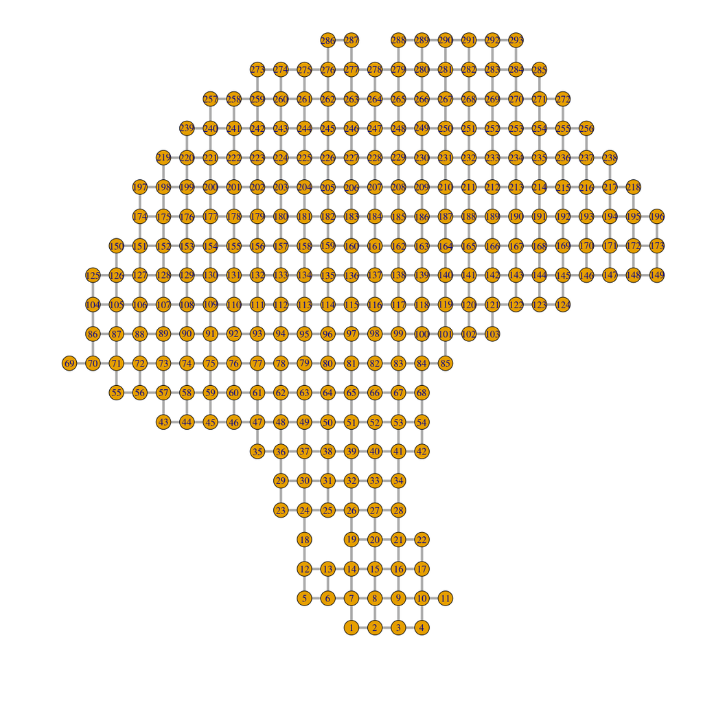

```r
g = graph_from_adjacency_matrix(A, 'undirected', add.colnames = NA, add.rownames = NA)
# manually set nodes x and y coordinates
vertex_attr(g, name = 'x') = local_df$x
vertex_attr(g, name = 'y') = local_df$y
plot(g, vertex.size=5, edge.width=4, margin=-0.05)
```

# 3 Proprocess reference scRNA-seq data

## 3.1 Read and preprocess scRNA-seq meta data

Original meta data file is [GSE115978_cell.annotations.csv.gz](https://www.ncbi.nlm.nih.gov/geo/download/?acc=GSE115978&format=file&file=GSE115978%5Fcell%2Eannotations%2Ecsv%2Egz) downloaded from GSE115978.

It contains meta data of 7,186 cells from human melanoma tumors. Based on [Table S1A. Clinical characteristics of the patients and samples in the scRNA-seq cohort](https://www.cell.com/cms/10.1016/j.cell.2018.09.006/attachment/9d59aec0-abbd-41db-9c3e-601af81698c1/mmc1.xlsx), We select samples for cell type deconvolution by following criteria:

1. Treatment: None;
2. Lesion type: metastasis;
3. Site: all kinds of lymph node.

8 samples (`Mel79`, `Mel80`, `Mel81`, `Mel82`, `Mel89`, `Mel103`, `Mel116`, `Mel128`) with **2,495 cells** are selected.

The cell type annotation is stored in column `cell.types`, which includes total 10 distinct annotations.

We selected 7 cell types as below:

1. malignant cells: “Mal”,
2. T cells: “T.cell” + “T.CD4” + “T.CD8”
3. B cells: “B.cell”
4. natural killer (NK) cells: “NK”
5. macrophages: “Macrophage”
6. cancer-associated fibroblasts (CAFs): “CAF”
7. endothelial cells: “Endo.”

We re-analysis the gene expression of selected **2,495** cells, cluster all cells into 10 clusters using TOP 5 PCs, and re-label the cells with unclear cell type “?” in each cluster as the dominate cell type of the cluster.

The refined cell type annotation of selected **2,495** cells is provided in Melanoma_ref_scRNA_cell_celltype.csv.

```r
file_name = file.path(home.dir, 'Melanoma_ref_scRNA_cell_celltype.csv')
ref_meta = read.csv(file_name, sep=',', check.names = F, header = T, row.names = 1)
print(sprintf('load data from %s', file_name))
```

```
[1] "load data from /home/hill103/Documents/SharedFolder/ToHost/CVAE-GLRM_Analysis/RealData/Melanoma/Melanoma_ref_scRNA_cell_celltype.csv"
```

```r
print(sprintf('total %d cells with distinct %d cell type annotations', nrow(ref_meta), length(unique(ref_meta$new_celltype))))
```

```
[1] "total 2495 cells with distinct 7 cell type annotations"
```

```r
table(ref_meta$new_celltype)
```

```
    B.cell        CAF      Endo. Macrophage        Mal         NK     T.cell
       364         48         34         62       1030         15        942
```

```r
ref_meta[1:5, 'new_celltype', drop=F]
```

|  | new_celltype |
| --- | --- |
| cy79_p4_CD45_neg_PDL1_neg_E11_S1115_comb | Mal |
| cy79_p1_CD45_neg_PDL1_pos_AS_C1_R1_F07_S67_comb | Mal |
| cy79_p1_CD45_neg_PDL1_pos_AS_C1_R1_G01_S73_comb | Mal |
| cy79_p1_CD45_neg_PDL1_neg_AS_C4_R1_D09_S141_comb | Mal |
| cy79_p1_CD45_neg_PDL1_neg_AS_C4_R1_D06_S138_comb | Mal |

## 3.2 Read and preprocess scRNA-seq nUMI data

Original gene nUMI count data file is [GSE115978_counts.csv.gz](https://www.ncbi.nlm.nih.gov/geo/download/?acc=GSE115978&format=file&file=GSE115978%5Fcounts%2Ecsv%2Egz) downloaded from GSE115978. It contains total 7,186 cells and 23,686 genes.

We just selected 2,495 cells of the selected 7 cell types by barcodes, and discard other cells. **NO filtering on genes**, i.e. all 23,686 genes will be used for cell type deconvolution.

```r
file_name = file.path(home.dir, 'GSE115978_counts.csv.gz')
ref_data = data.table::fread(file_name, sep = ",", check.names = FALSE)
gene_names = ref_data$V1
cell_names = colnames(ref_data)[2:ncol(ref_data)]

# transpose it
ref_data = as.data.frame(data.table::transpose(ref_data %>%
  select(cell_names)))

row.names(ref_data) = cell_names
colnames(ref_data) = gene_names

print(sprintf('load data from %s', file_name))
```

```
[1] "load data from /home/hill103/Documents/SharedFolder/ToHost/CVAE-GLRM_Analysis/RealData/Melanoma/GSE115978_counts.csv.gz"
```

```r
print(sprintf('total cells: %d; genes: %d', nrow(ref_data), ncol(ref_data)))
```

```
[1] "total cells: 7186; genes: 23686"
```

Select cells and save scRNA-seq nUMI matrix to file Melanoma_ref_scRNA_cell_nUMI.csv.gz

```r
ref_data = ref_data[row.names(ref_meta), ]

ref_data[1:5, 1:5]
```

|  | C9orf152 | RPS11 | ELMO2 | CREB3L1 | PNMA1 |
| --- | --- | --- | --- | --- | --- |
| cy79_p4_CD45_neg_PDL1_neg_E11_S1115_comb | 0 | 1 | 0 | 0 | 0 |
| cy79_p1_CD45_neg_PDL1_pos_AS_C1_R1_F07_S67_comb | 0 | 15 | 18 | 0 | 8 |
| cy79_p1_CD45_neg_PDL1_pos_AS_C1_R1_G01_S73_comb | 0 | 13 | 4 | 0 | 8 |
| cy79_p1_CD45_neg_PDL1_neg_AS_C4_R1_D09_S141_comb | 0 | 5 | 4 | 0 | 0 |
| cy79_p1_CD45_neg_PDL1_neg_AS_C4_R1_D06_S138_comb | 0 | 2 | 0 | 0 | 0 |

```r
data.table::fwrite(ref_data, 'Melanoma_ref_scRNA_cell_nUMI.csv.gz', row.names = T)
print(sprintf('save nUMI matrix of reference scRNA-seq cells into gzip compressed file %s', 'Melanoma_ref_scRNA_cell_nUMI.csv.gz'))
```

```
[1] "save nUMI matrix of reference scRNA-seq cells into gzip compressed file Melanoma_ref_scRNA_cell_nUMI.csv.gz"
```